# Stemcell Timecourse: Intronic Expression

Badoi and Steve

February 26, 2016

## Set-up

First we load in the RPKM intronic data and the phenotype data for the stem-cells included in this analysis.

```r
#setwd('/dcl01/lieber/ajaffe/lab/libd_stem_timecourse/')
# intron expression in human stem cells
dir = '/dcl01/lieber/ajaffe/Emily/RNAseq-pipeline/Projects/AZpilot_stemcell/'
#load phenotype data
load('/dcl01/lieber/ajaffe/lab/libd_stem_timecourse/prep_samples/annotated_phenotype_data_stemCellTimecourse.rda')
# load data files from intron featureCounts
load(paste0(dir,'intron_rpkmCounts_AZpilot_feb22.hg38.intron_n506.rda'))
library(ggplot2)
library(dplyr)
library(tidyr)
theme_set(theme_bw(base_size=10) +
          theme(panel.grid.major = element_blank(),
                panel.grid.minor = element_blank(),
                 plot.title = element_text(hjust = 0.5),
                legend.position="none"))
```

Then we subset to non-replicates and fix some variable types.

```r
# take only biological replicates
bioInd = which(pd$Class == "Naked genomes")
pd = pd[bioInd,]
pd$DAY = as.numeric(pd$DAY)
pd$DX = factor(pd$DX,levels = c('CNT','SCZ'))
pd$Donor = factor(pd$Donor)
pd$totalAssignedIntron = metrics[pd$SAMPLE_ID,'totalAssignedIntron']
```

The `intronRpkm` object is subsetted to include only the stem-cells of interest.

```r
intronRpkm = intronRpkm[,pd$SAMPLE_ID]
```

## Exploratory Data Analysis

### Average RPKM Distribution

We are interested in the distribution of intronic RPKM because it may help us pick a suitable filter to exclude biologically irrelevant data.

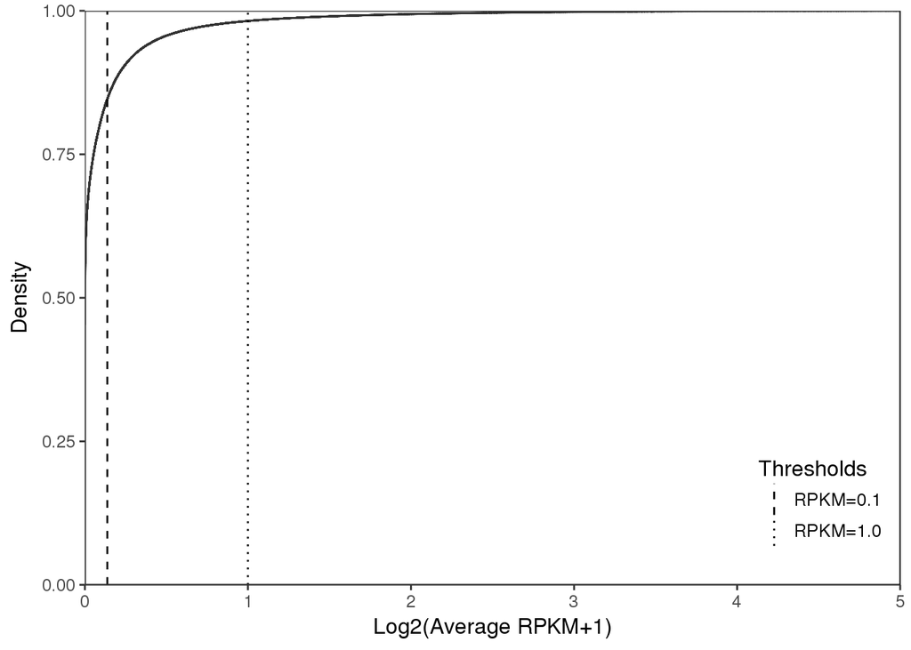

```r
############################## Plot average RPKM distribution before filtering
#setwd('/users/ssemick/StemCell')
library(ggplot2)
intron_rowmean <- as.data.frame(log2(rowMeans(intronRpkm)+1))
colnames(intron_rowmean) <-"Rowmean"
rpkm_density <- ggplot(data = intron_rowmean, aes(x = Rowmean))
rpkm_density <- rpkm_density + stat_ecdf(geom = "step", alpha = .8) +
                               geom_vline(data= data.frame(Thresholds=c("RPKM=0.1","RPKM=1.0"),vals = c(log2(0.1 +1),log2(1.0 +1))),aes(xintercept=vals, linetype=Thresholds), colour = "black", show.legend=TRUE) +
                               guides(fill=FALSE) +
                               labs(x = "Log2(Average RPKM+1)",
                                    y = "Density")+
                                theme_bw(base_size = 12) +
                                theme(plot.title = element_text(hjust = 0.5),
                                panel.grid.major = element_blank(),
                                panel.grid.minor = element_blank(),
                                legend.title=element_text(size=12),
                                legend.text=element_text(size=10),
                                legend.justification=c(1,0),
                                legend.position=c(.99,.05)) +
                                scale_colour_brewer(palette = "Set1") +
                                scale_fill_brewer(palette = "Set1") +
                                scale_linetype_manual(values=c(2,3)) +
                                scale_y_continuous(expand = c(0, 0), limits = c(0, 1)) +
                                scale_x_continuous(expand = c(0, 0), limits = c(0, 5))
                            #   coord_cartesian(xlim = c(0, 10))
ggsave(rpkm_density, filename="plots/Intron Distribution.pdf", width=11,height=8.5)
rpkm_density
```

### Intronic RPKM Filter

We decide to filter intron RPKM using a cutoff of 0.1

```r
keepIndex = which(rowMeans(intronRpkm)>0.1)
intronRpkm = intronRpkm[keepIndex,]
```

### Exploratory Plots

We performed principle components analysis on the introns that remained after filtering. Then we plotted the PCA components against stem-cell timecourse information. We also checked whether the time biased in-sillico RNA quality measures.

```r
# make some plots
library(RColorBrewer)
library(ggplot2)
pca = prcomp(t(intronRpkm))

pdf('plots/stem_cell_intron_timecourse_expression.pdf')
ggplot(data = data.frame(pca$x,pd))+
  geom_point(aes(x=PC1,y=PC2,fill=factor(DAY),shape = DX))+
  scale_fill_brewer(palette = 'PiYG') +
  scale_shape_manual(values = c(21,24))

ggplot(data = data.frame(pca$x,pd),aes(x=DAY,y=PC1))+
  geom_point(pch=21,aes(fill=Donor),position = position_dodge(width = .25))+
  scale_fill_brewer(palette = 'Set1')

pd$meanRpkm = colMeans(intronRpkm)
ggplot(data = pd,aes(x=DAY,y=meanRpkm,color = Donor))+
  geom_line()+ scale_colour_brewer(palette = 'Set1') +
  ggtitle('Mean RPKM')

ggplot(data = pd,aes(x=DAY,y=totalAssignedIntron,color = Donor))+
  geom_line()+ scale_colour_brewer(palette = 'Set1') +
  ggtitle('Intron Assignment Rate')
dev.off()
```

## Intronic Expression Across Condition (Factor Model)

We ran a linear model using `limma` to see how different stem-cell conditions, via a non-ordinal factor model, affected intronic expression.

We first subbsetted to the stem-cells of interest.

```r
library(limma)
library(edgeR)
load(paste0(dir,'intron_rawCounts_AZpilot_feb22.hg38.intron_n506.rda'))
pd2<-pd
intronCounts2<-intronCounts[,pd2$SAMPLE_ID]
dge <- DGEList(counts = intronCounts2, group = pd2$CONDITION)
```

The modelling was done on intronic counts *not intronic RPKM*, and we plotted the distribution of intronic counts to find a suitable filtering cutoff. As suggested by the `limma` users guide we filtered based on average counts per million (cpm).

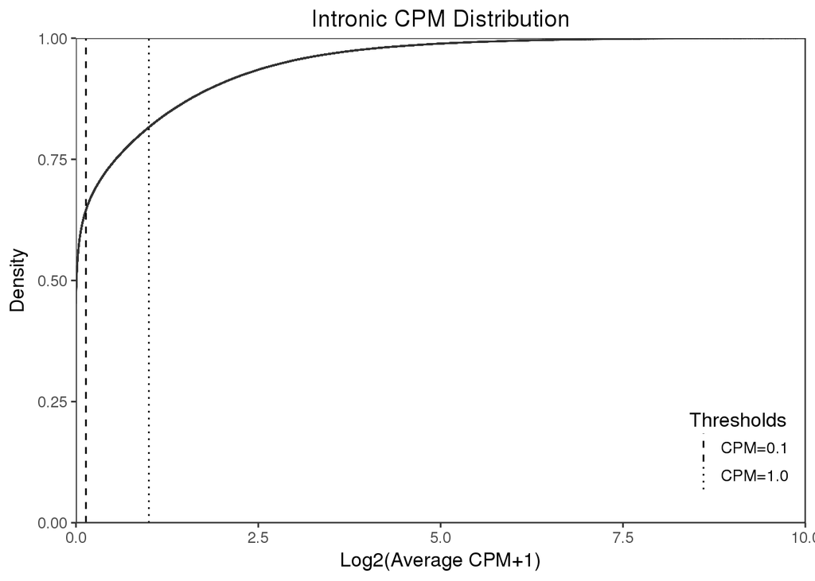

```r
#Plot for filtering cutoff
intron_count_rowmean <- as.data.frame(log2(rowMeans(cpm(dge))+1))
colnames(intron_count_rowmean) <-"Rowmean"
rpkm_density <- ggplot(data = intron_count_rowmean, aes(x = Rowmean))
rpkm_density <- rpkm_density + stat_ecdf(geom = "step", alpha = .8) +
                               geom_vline(data= data.frame(Thresholds=c("CPM=0.1","CPM=1.0"),vals = c(log2(0.1 +1),log2(1.0 +1))),aes(xintercept=vals, linetype=Thresholds), colour = "black", show.legend=TRUE) +
                               guides(fill=FALSE) +
                               labs(x = "Log2(Average CPM+1)",
                                    y = "Density")+
                                theme_bw(base_size = 12) +
                                theme(plot.title = element_text(hjust = 0.5),
                                panel.grid.major = element_blank(),
                                panel.grid.minor = element_blank(),
                                legend.title=element_text(size=12),
                                legend.text=element_text(size=10),
                                legend.justification=c(1,0),
                                legend.position=c(.99,.05)) +
                                scale_colour_brewer(palette = "Set1") +
                                scale_fill_brewer(palette = "Set1") +
                                scale_linetype_manual(values=c(2,3)) +
                                scale_y_continuous(expand = c(0, 0), limits = c(0, 1)) +
                                scale_x_continuous(expand = c(0, 0), limits = c(0, 10))
                            #   coord_cartesian(xlim = c(0, 10))
ggsave(rpkm_density, filename="plots/Intron Count Per Million Distribution.pdf", width=11,height=8.5)
rpkm_density +ggtitle("Intronic CPM Distribution")
```

Based on the plotted distribution we choose to use a `cpm` threshold of 0.5, and thus excluded all introns with average cpm less than 0.5 in further analysis.

```r
keep <- rowMeans(cpm(dge)) >.5
pd2$CONDITION <-factor(pd2$CONDITION,levels=c("RENEW","ACC_DORSAL(2)","NPC","ROSETTE","NEURONS_ALONE","NEURONS_PLUS_ASTROS"))

###From user manual
dge <- dge[keep,,keep.lib.sizes=FALSE]
```

To normalize intron counts we used limma’s `voom` transformation. Our model adjusts for `LINE` and `totalAssignedIntron` (a measure of RNA quality).

```r
#Factor Model
# Model Matrix
design = model.matrix(~ pd2$CONDITION  + pd2$LINE +pd2$totalAssignedIntron)
pdf("plots/Limma_Voom_Introns_Plot.pdf",width=11,height=8.5)
v <- voom(dge, design, plot=TRUE)
dev.off()
```

We then ran a linear model (`lmFit`) through an emprical bayes framework (`eBayes`). We saved out our results and made appropriate plots.

```r
#Model fitting
fit <- lmFit(v, design)
fit2 <- eBayes(fit)
top <- topTable(fit2, coef=2, sort.by = 'p',number=Inf)
top<-cbind(top,intronMap[rownames(top),])
write.csv(top,file="csvs/Introns_Differential_Expression_Results_byCondition_FactorModel.csv")
DT::datatable(top[1:1000,c('Symbol',colnames(top)[!colnames(top)%in%'Symbol']  ) ])
```

|  | Symbol | logFC | AveExpr | t | P.Value | adj.P.Val | B | Chr | Start | End | Strand | Length | gencodeID | ensemblID | gene_type | EntrezID | Class | meanExprs | NumTx | gencodeTx |
| --- | --- | --- | --- | --- | --- | --- | --- | --- | --- | --- | --- | --- | --- | --- | --- | --- | --- | --- | --- | --- |
| i125361 | TRDN | -4.86068419933054 | -2.41215835140288 | -13.7688923346026 | 4.81553585362571e-27 | 4.10779654921834e-22 | 48.8801379727609 | chr6 | 123464984 | 123503718 | - | 38735 | ENSG00000186439.12 | ENSG00000186439 | protein_coding | 10345 | InGen | 0.00192545123235134 | 0 |  |
| i43531 | SLC39A10 | -5.92549956268671 | -1.55223081026269 | -13.0522122414814 | 2.68810495894548e-25 | 1.14651708656463e-20 | 45.9604379207488 | chr2 | 195576083 | 195606135 | + | 30053 | ENSG00000196950.13 | ENSG00000196950 | protein_coding | 57181 | InGen | 0.0148383541711841 | 0 |  |
| i125356 | TRDN | -4.91633708173925 | -2.07544919309127 | -12.7334146816222 | 1.62708655636636e-24 | 3.48329044832875e-20 | 43.7945739710182 | chr6 | 123516207 | 123530505 | - | 14299 | ENSG00000186439.12 | ENSG00000186439 | protein_coding | 10345 | InGen | 0.0123677118606224 | 0 |  |
| i69125 | SKIL | -2.54216655093898 | 3.72407951500249 | -12.7327330765233 | 1.6333730107165e-24 | 3.48329044832875e-20 | 45.1612246561864 | chr3 | 170381342 | 170390222 | + | 8881 | ENSG00000136603.13 | ENSG00000136603 | protein_coding | 6498 | InGen | 0.224366044222421 | 0 |  |
| i119331 | SERPINB9 | -3.57777652368419 | -1.14509849726967 | -12.2469230130587 | 2.56693131636808e-23 | 4.37933884160292e-19 | 41.2749367882671 | chr6 | 2890571 | 2891832 | - | 1262 | ENSG00000170542.5 | ENSG00000170542 | protein_coding | 5272 | InGen | 0.0783317741514404 | 0 |  |
| i69122 | SKIL | -2.40796172970497 | 3.61208952035035 | -11.9076218078258 | 1.76851862077363e-22 | 2.51433239846421e-18 | 40.543269131204 | chr3 | 170359877 | 170360367 | + | 491 | ENSG00000136603.13 | ENSG00000136603 | protein_coding | 6498 | InGen | 4.2100753367682 | 0 |  |
| i119332 | SERPINB9 | -3.83855521278696 | -1.65832481397895 | -11.8757771259571 | 2.12014098414908e-22 | 2.58363409101241e-18 | 39.0916762458814 | chr6 | 2891989 | 2893410 | - | 1422 | ENSG00000170542.5 | ENSG00000170542 | protein_coding | 5272 | InGen | 0.0779909550336091 | 0 |  |
| i72277 | OSBPL10 | -4.39107915182132 | -1.77573708807882 | -11.8396289577426 | 2.60482396127946e-22 | 2.77749122961277e-18 | 39.3519913929521 | chr3 | 31876513 | 31980898 | - | 104386 | ENSG00000144645.13 | ENSG00000144645 | protein_coding | 114884 | InGen | 0.00123379804714411 | 0 |  |
| i307334 | NCR1 | -4.6951883709007 | -2.38105411335683 | -11.5688905805289 | 1.21873324667987e-21 | 1.1551289126837e-17 | 37.4834080471425 | chr19 | 54913156 | 54915749 | + | 2594 | ENSG00000189430.12 | ENSG00000189430 | protein_coding | 9437 | InGen | 0.0364495595518575 | 0 |  |
| i125357 | TRDN | -4.63644424995445 | -2.20356524957943 | -11.3919799415799 | 3.34286382945805e-21 | 2.8515631324426e-17 | 36.549821021724 | chr6 | 123530566 | 123547339 | - | 16774 | ENSG00000186439.12 | ENSG00000186439 | protein_coding | 10345 | InGen | 0.00942461384667041 | 0 |  |

[output cut: 990 more lines]

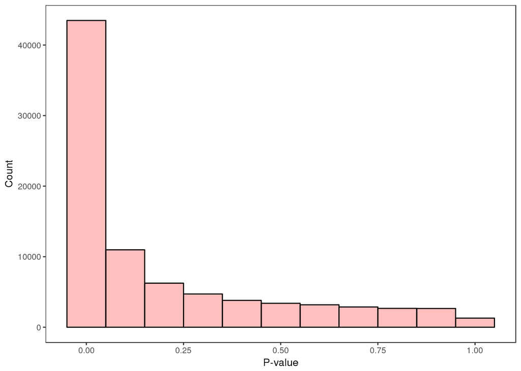

```r
factor_phist <- ggplot(data=top, aes(x=P.Value))
factor_phist <- factor_phist + geom_histogram( binwidth=0.1,
                                linetype=1,
                                alpha=.25,
                                color="black",
                                fill="red") +
                                labs(x="P-value",
                                     y= "Count")+
                                scale_y_continuous() +
                                scale_x_continuous()
ggsave(factor_phist, filename = "plots/factor_model_histogram_pvalues.pdf", width=11,height=8.5)
factor_phist
```

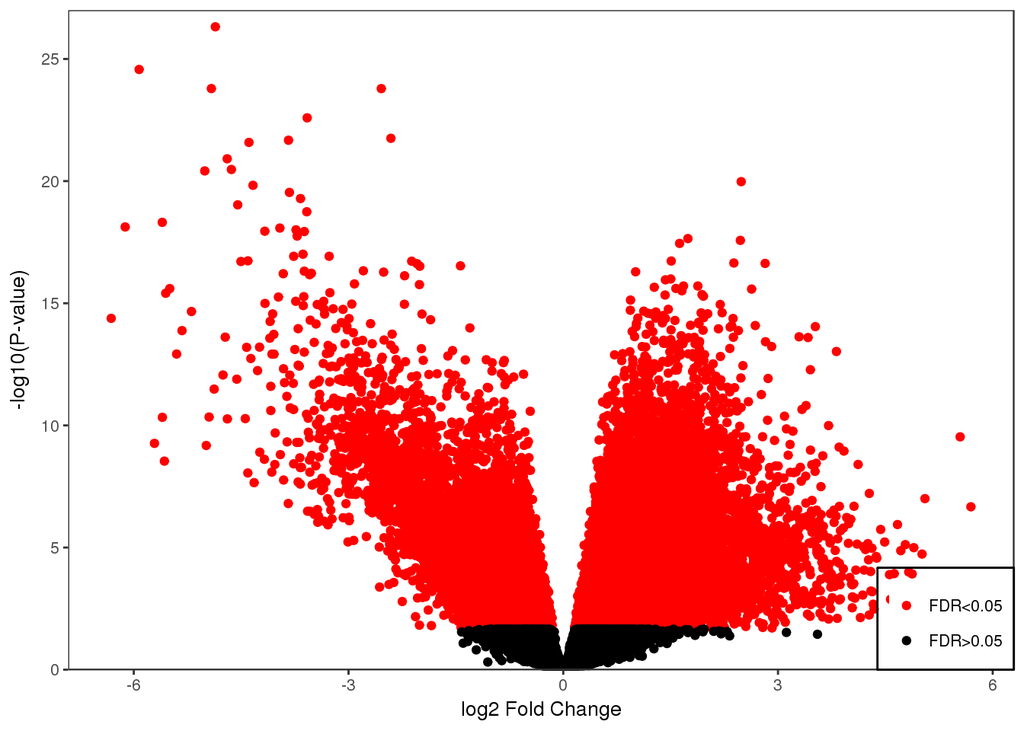

```r
top$sig = factor(ifelse(top$adj.P.Val<0.05, "FDR<0.05", "FDR>0.05"),levels=c("FDR<0.05","FDR>0.05"))
intron_volc <- ggplot(top, aes(logFC, -log10(P.Value))) +
  geom_point(aes(col=sig)) +
  theme(legend.justification = c(1, 0),
        legend.position = c(1, 0),
        legend.background = element_rect(fill=NA, size=.5, linetype="solid")) +
  labs(x = "log2 Fold Change",
       y = "-log10(P-value)") +
  scale_color_manual(values=c("red", "black")) +
    scale_y_continuous(expand = c(0, 0), limits = c(0, max(round(-log10(top$P.Value)))+1)) +
  theme(legend.background = element_rect(colour = "black"),
        legend.title=element_blank()) #no legend title
ggsave(intron_volc, filename = "plots/factor_model_volcano_plot_allConditions.pdf", width=11,height=8.5)
intron_volc
```

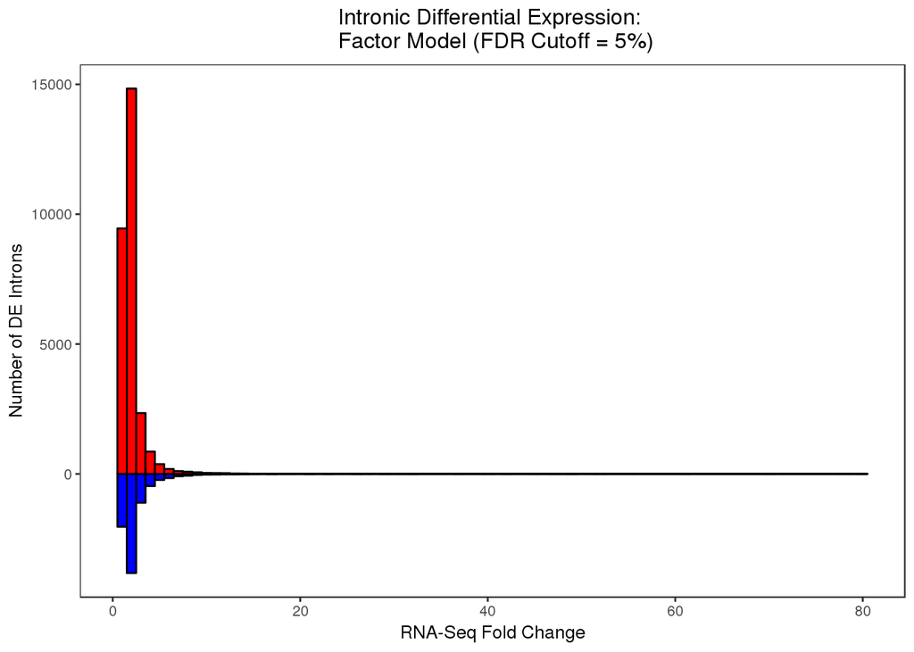

```r
histo_intron <- ggplot() +
                geom_histogram(data = top[which(top$logFC < 0 & top$adj.P.Val <0.05), ],
                          aes(x = 2^abs(logFC), y = -..count..),
                          binwidth=1,
                          fill = "blue",
                          color = "black") +
#               geom_density(data = top[which(top$logFC < 0 & top$adj.P.Val <0.05), ],
#                            aes(x = 2^abs(logFC), y=-..count.. )) +  # Overlay with transparent density plot
                geom_histogram(data = top[which(top$logFC > 0 & top$adj.P.Val <0.05), ],
                          aes(x = 2^logFC, y = ..count..),
                          binwidth=1,
                          fill = "red",
                          color = "black")+
#               geom_density(data = top[which(top$logFC > 0 & top$adj.P.Val <0.05), ])+  # Overlay with transparent density plot
            labs(x = "RNA-Seq Fold Change",
                 y = "Number of DE Introns",
                 title = "Intronic Differential Expression: \n Factor Model (FDR Cutoff = 5%)")
ggsave(histo_intron, filename = "plots/factor_model_intron_DE_Histogram.pdf", width=11,height=8.5)
histo_intron
```

## Intronic Expression Across Condition (Ordinal Model)

We then repeated our analysis, now with an ordinal model. We used the following series as a first pass: 1) RENEW 2) ACC_DORSAL 3) NPC 4) ROSETTE 5) NEURONS_ALONE 6) NEURON_PLUS_ASTROS

Set-up the design matrix and `voom` normalize the intron count data.

```r
# Model Matrix
design = model.matrix(~ as.numeric(pd2$CONDITION)  + pd2$LINE +pd2$totalAssignedIntron)
pdf("plots/Limma_Voom_Introns_Plot_OrdinalFactor.pdf",width=11,height=8.5)
v <- voom(dge, design, plot=TRUE)
dev.off()
```

Fit the ordinal model (all conditions).

```r
fit <- lmFit(v, design)
fit2 <- eBayes(fit)
top <- topTable(fit2, coef=2, sort.by = 'p',number=Inf)
top<-cbind(top,intronMap[rownames(top),])
write.csv(top,file="csvs/Introns_Differential_Expression_Results_byCondition_OrdinalModel.csv")
DT::datatable(top[1:1000, c('Symbol',colnames(top)[!colnames(top)%in%'Symbol']  )])
```

|  | Symbol | logFC | AveExpr | t | P.Value | adj.P.Val | B | Chr | Start | End | Strand | Length | gencodeID | ensemblID | gene_type | EntrezID | Class | meanExprs | NumTx | gencodeTx |
| --- | --- | --- | --- | --- | --- | --- | --- | --- | --- | --- | --- | --- | --- | --- | --- | --- | --- | --- | --- | --- |
| i108858 | LRRTM2 | 2.65690051160985 | -0.680609776869319 | 48.3354313081819 | 4.13270918490875e-85 | 3.52532491600271e-80 | 182.860974637774 | chr5 | 138873240 | 138874907 | - | 1668 | ENSG00000146006.7 | ENSG00000146006 | protein_coding | 26045 | InGen | 0.461038212459583 | 0 |  |
| i87948 | GRIA2 | 2.78847853349639 | -0.193904606039561 | 38.5800831589385 | 3.5214217488111e-73 | 1.50193919719417e-68 | 156.275604730301 | chr4 | 157336748 | 157341263 | + | 4516 | ENSG00000120251.18 | ENSG00000120251 | protein_coding | 2891 | InGen | 0.288827135761374 | 0 |  |
| i333297 | CSDC2 | 1.36812504893463 | 3.05249910633703 | 38.1576585496205 | 1.3175305584546e-72 | 3.7463103075951e-68 | 155.399621164456 | chr22 | 41573778 | 41577268 | + | 3491 | ENSG00000172346.14 | ENSG00000172346 | protein_coding | 27254 | InGen | 0.482907319468545 | 0 |  |
| i87947 | GRIA2 | 2.34225443416089 | -1.33965253354715 | 37.4271771989029 | 1.32842887170622e-71 | 2.8329742010789e-67 | 152.394580099766 | chr4 | 157335878 | 157336376 | + | 499 | ENSG00000120251.18 | ENSG00000120251 | protein_coding | 2891 | InGen | 0.558059656924309 | 0 |  |
| i103120 |  | 3.03549000037627 | 3.60859677808945 | 37.0232484000967 | 4.84502357348323e-71 | 8.2659009177768e-67 | 151.798436445252 | chr5 | 174064316 | 174205199 | + | 140884 | ENSG00000170091.10 | ENSG00000170091 | protein_coding | 51617 | InGen | 0.224323376214913 | 0 |  |
| i62277 | ARPP21 | 2.14151270283073 | -0.865872741089811 | 35.9081439161 | 1.83388818365812e-69 | 2.60726939550981e-65 | 147.692472294651 | chr3 | 35639032 | 35679786 | + | 40755 | ENSG00000172995.16 | ENSG00000172995 | protein_coding | 10777 | InGen | 0.00804053629144382 | 0 |  |
| i2362 | CDC42 | 1.84943159982743 | 3.69558004416991 | 35.5160042008024 | 6.72788525924066e-69 | 8.19869708955724e-65 | 146.863433564875 | chr1 | 22086867 | 22091427 | + | 4561 | ENSG00000070831.15 | ENSG00000070831 | protein_coding | 998 | InGen | 1.08556342409099 | 0 |  |
| i47638 | KIDINS220 | 0.74483739652254 | 8.22143207725606 | 34.1238010014794 | 7.47745656398321e-67 | 7.97311846596825e-63 | 141.979171130558 | chr2 | 8726944 | 8733443 | - | 6500 | ENSG00000134313.14 | ENSG00000134313 | protein_coding | 57498 | InGen | 6.76161734095326 | 0 |  |
| i87950 | GRIA2 | 2.33107393424842 | -1.36162552962895 | 33.7686322744639 | 2.54920639725971e-66 | 2.41616614783828e-62 | 140.469980394155 | chr4 | 157360144 | 157361537 | + | 1394 | ENSG00000120251.18 | ENSG00000120251 | protein_coding | 2891 | InGen | 0.236399346062624 | 0 |  |
| i87935 | GRIA2 | 2.75024886057297 | -0.671401189247872 | 33.5761520270468 | 4.97666429907312e-66 | 4.24524394703834e-62 | 139.972395889489 | chr4 | 157204436 | 157303551 | + | 99116 | ENSG00000120251.18 | ENSG00000120251 | protein_coding | 2891 | InGen | 0.011636341832454 | 0 |  |

[output cut: 990 more lines]

Several plots for ordinal model.

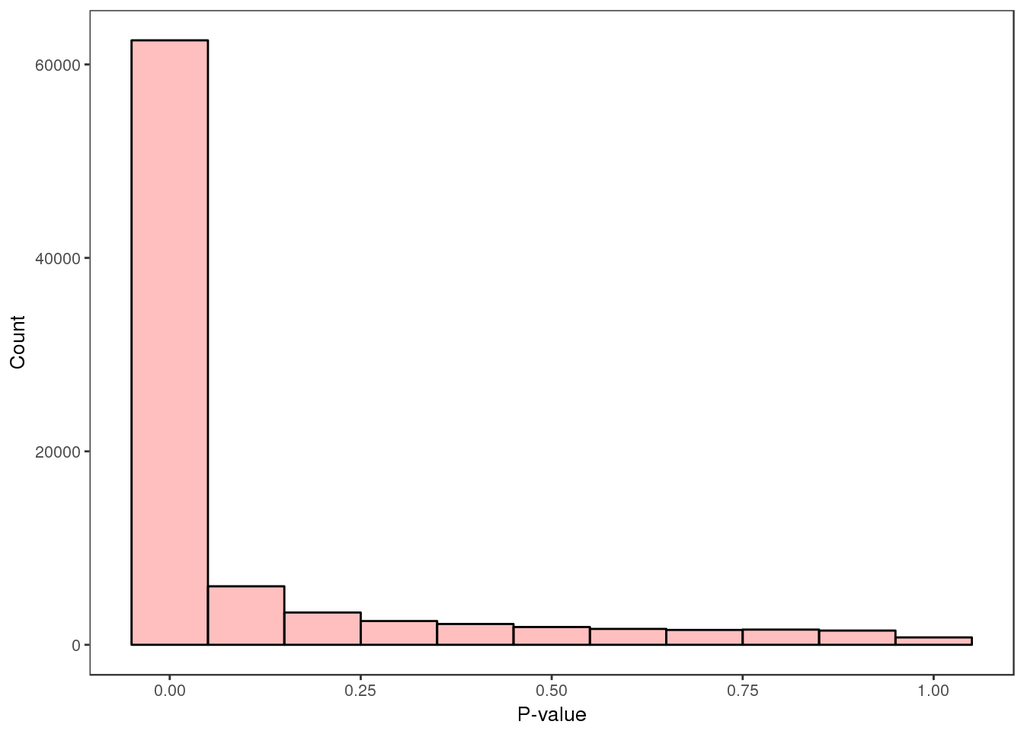

```r
factor_phist <- ggplot(data=top, aes(x=P.Value))
factor_phist <- factor_phist + geom_histogram( binwidth=0.1,
                                linetype=1,
                                alpha=.25,
                                color="black",
                                fill="red") +
                                labs(x="P-value",
                                     y= "Count")+
                                scale_y_continuous() +
                                scale_x_continuous()
ggsave(factor_phist, filename = "plots/ordinal_model_histogram_pvalues.pdf", width=11,height=8.5)
factor_phist
```

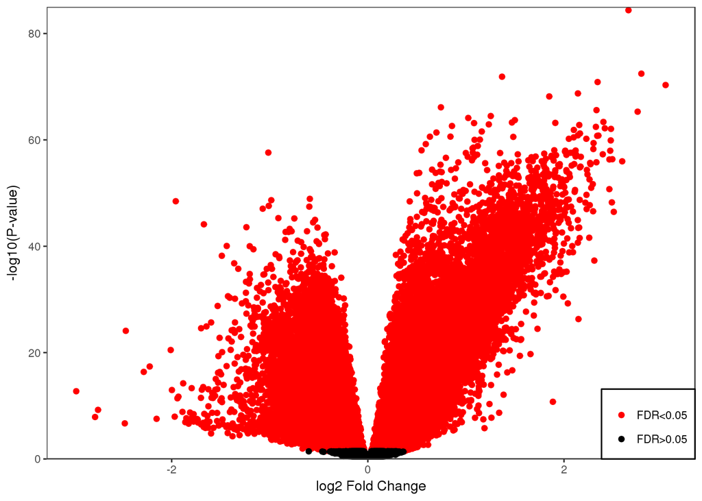

```r
top$sig = factor(ifelse(top$adj.P.Val<0.05, "FDR<0.05", "FDR>0.05"),levels=c("FDR<0.05","FDR>0.05"))
intron_volc <- ggplot(top, aes(logFC, -log10(P.Value))) +
  geom_point(aes(col=sig)) +
  theme(legend.justification = c(1, 0),
        legend.position = c(1, 0),
        legend.background = element_rect(fill=NA, size=.5, linetype="solid")) +
  labs(x = "log2 Fold Change",
       y = "-log10(P-value)") +
  scale_color_manual(values=c("red", "black")) +
    scale_y_continuous(expand = c(0, 0), limits = c(0, max(round(-log10(top$P.Value)))+1)) +
  theme(legend.background = element_rect(colour = "black"),
        legend.title=element_blank()) #no legend title
ggsave(intron_volc, filename = "plots/ordinal_model_volcano_plot_allConditions.pdf", width=11,height=8.5)
intron_volc
```

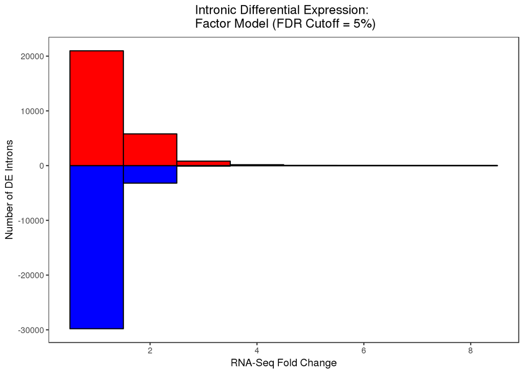

```r
histo_intron <- ggplot() +
                geom_histogram(data = top[which(top$logFC < 0 & top$adj.P.Val <0.05), ],
                          aes(x = 2^abs(logFC), y = -..count..),
                          binwidth=1,
                          fill = "blue",
                          color = "black") +
#               geom_density(data = top[which(top$logFC < 0 & top$adj.P.Val <0.05), ],
#                            aes(x = 2^abs(logFC), y=-..count.. )) +  # Overlay with transparent density plot
                geom_histogram(data = top[which(top$logFC > 0 & top$adj.P.Val <0.05), ],
                          aes(x = 2^logFC, y = ..count..),
                          binwidth=1,
                          fill = "red",
                          color = "black")+
#               geom_density(data = top[which(top$logFC > 0 & top$adj.P.Val <0.05), ])+  # Overlay with transparent density plot
            labs(x = "RNA-Seq Fold Change",
                 y = "Number of DE Introns",
                 title = "Intronic Differential Expression: \n Factor Model (FDR Cutoff = 5%)")
ggsave(histo_intron, filename = "plots/ordinal_model_intron_DE_Histogram.pdf", width=11,height=8.5)
histo_intron
```

```r
counts <- dge$counts
#residualCounts<-jaffelab::cleaningY(y = counts(ER_dds,normalized=TRUE), mod=mod, P=ncol(mod)-2)
top$row <- rownames(top)
res <- as.data.frame(top) %>%
  arrange(adj.P.Val, P.Value) %>%
  tbl_df()
topRes <- res[1:100,]

rownames(pd2) <-pd2$SAMPLE_ID
goi <- topRes$row
tcounts <- t(dge$counts[goi,]) %>%
  merge(pd2, ., by="row.names") %>%
  gather(key=gene, value=expression, (ncol(.)-length(goi)+1):ncol(.))

pdf("plots/top10Introns_Boxplot_Catalog.pdf")
for (i in goi) {
  p <- ggplot(filter(tcounts, gene==i), aes(x=CONDITION, y=expression)) +
       geom_boxplot(outlier.colour = NA, alpha = 0.1, aes(fill = CONDITION)) +
        geom_point(alpha = 1, aes(colour = CONDITION), position = position_jitter(width = 0.2)) +
        labs(x = "Condition Group",
             y = "Intron Counts",
             title = paste0("Intron: ", ifelse(top[i,'Symbol'] !="", top[i,'Symbol'],top[i,'ensemblID']) )) +
        scale_colour_brewer(palette = "Set1") +
        scale_fill_brewer(palette = "Set1") +
        theme(axis.text.x = element_text(angle = 45, hjust = 1)) +
        geom_text(aes(x=Inf,y=Inf,hjust=1.1,vjust=1.1,label=paste0("p=", signif(top[i,'P.Value'],3) ) ))+
        scale_y_log10()
  print(p)
}
dev.off()
```

## No ACCDORSAL Ordinal Model

Next we used a more complex model. First removed all `ACC_DORSAL` stem-cells, then we created a binary variable for astrocytes and combined neurons+astrocytes and neurons without astrocytes into a single condition, using the astrocyte indicator variable to retain the astrocyte information (as a covariate).

```r
pd2<-pd[pd$CONDITION!="ACC_DORSAL(2)",]
intronCounts2<-intronCounts[,pd2$SAMPLE_ID]

pd2$CONDITION <-factor(pd2$CONDITION,levels=c("RENEW","NPC","ROSETTE","NEURONS_ALONE","NEURONS_PLUS_ASTROS"))
pd2$Astrocytes <- ifelse(pd2$CONDITION=="NEURONS_PLUS_ASTROS", "Astrocytes", "No Astrocytes")
pd2$CONDITION <- plyr::revalue(pd2$CONDITION, c("NEURONS_ALONE"="NEURONS", "NEURONS_PLUS_ASTROS"="NEURONS" ))
dge <- DGEList(counts = intronCounts2, group = pd2$CONDITION)
```

We filtered as before `cpm>0.5`.

```r
keep <- rowMeans(cpm(dge)) >.5
dge <- dge[keep,,keep.lib.sizes=FALSE]
```

```r
# Model Matrix
design = model.matrix(~ as.numeric(pd2$CONDITION) + pd2$LINE +pd2$totalAssignedIntron +pd2$Astrocytes)
pdf("plots/Limma_Voom_Introns_Plot_No_ACCDORSAL_Interaction.pdf",width=11,height=8.5)
v <- voom(dge, design, plot=TRUE)
dev.off()
```

We fit the ordinal model to the non acc_dorsal stemcells. Adjusting for astrocyte presence, intron assignment rate, and line.

```r
#Model fitting
fit <- lmFit(v, design)
fit2 <- eBayes(fit)
top <- topTable(fit2, coef=2, sort.by = 'p',number=Inf)
top<-cbind(top,intronMap[rownames(top),])
write.csv(top,file="csvs/Introns_Differential_Expression_Results_byCondition_OrdinalModel_No_ACCDORSAL.csv")
DT::datatable(top[1:1000, c('Symbol',colnames(top)[!colnames(top)%in%'Symbol']  ) ])
```

|  | Symbol | logFC | AveExpr | t | P.Value | adj.P.Val | B | Chr | Start | End | Strand | Length | gencodeID | ensemblID | gene_type | EntrezID | Class | meanExprs | NumTx | gencodeTx |
| --- | --- | --- | --- | --- | --- | --- | --- | --- | --- | --- | --- | --- | --- | --- | --- | --- | --- | --- | --- | --- |
| i108858 | LRRTM2 | 3.30760130970368 | 1.6205595347727 | 23.1153691324504 | 1.48271698001003e-36 | 1.2573736533881e-31 | 71.9229206693852 | chr5 | 138873240 | 138874907 | - | 1668 | ENSG00000146006.7 | ENSG00000146006 | protein_coding | 26045 | InGen | 0.461038212459583 | 0 |  |
| i115781 | RIMS1 | 1.55899716981269 | 5.90101339345585 | 21.7231242315002 | 9.75011092411347e-35 | 4.13414453293335e-30 | 68.7806955055752 | chr6 | 72292047 | 72390597 | + | 98551 | ENSG00000079841.18 | ENSG00000079841 | protein_coding | 22999 | InGen | 0.0688834362368034 | 0 |  |
| i2864 | LIN28A | -3.05440069613365 | 2.10924453925492 | -21.4318594644403 | 2.39893775333798e-34 | 6.78115731195224e-30 | 67.7198614886414 | chr1 | 26428588 | 26429095 | + | 508 | ENSG00000131914.10 | ENSG00000131914 | protein_coding | 79727 | InGen | 29.8211130154277 | 0 |  |
| i341301 | ARMCX5-GPRASP2 | 1.16220349881872 | 7.49893205757621 | 20.8444893141849 | 1.51427117470504e-33 | 3.21033060393342e-29 | 65.9866688722922 | chrX | 102605654 | 102713781 | + | 108128 | ENSG00000271147.7 | ENSG00000271147 | processed_transcript |  | InGen | 0.209904055837408 | 0 |  |
| i9096 | MAN1A2 | 1.11847536494878 | 6.94363742870307 | 20.245629357872 | 1.02915727851906e-32 | 1.6834009084538e-28 | 64.0666568605225 | chr1 | 117368486 | 117414712 | + | 46227 | ENSG00000198162.12 | ENSG00000198162 | protein_coding | 10905 | InGen | 0.423569541252755 | 0 |  |
| i272360 | CHD3 | 1.48412031623694 | 7.11657311500208 | 20.2004673295908 | 1.19105745745653e-32 | 1.6834009084538e-28 | 63.9215621053777 | chr17 | 7905990 | 7906552 | + | 563 | ENSG00000170004.16 | ENSG00000170004 | protein_coding | 1107 | InGen | 23.8327154394072 | 0 |  |
| i87948 | GRIA2 | 3.39341079561381 | 2.04420742384609 | 18.5166509425994 | 3.25626830229365e-30 | 3.94482949387294e-26 | 58.0391208178948 | chr4 | 157336748 | 157341263 | + | 4516 | ENSG00000120251.18 | ENSG00000120251 | protein_coding | 2891 | InGen | 0.288827135761374 | 0 |  |
| i304412 | CYP2S1 | -3.17471566059934 | 1.46002546734683 | -18.4209134105169 | 4.52415718825136e-30 | 4.79571972347615e-26 | 57.7660108859816 | chr19 | 41193442 | 41201230 | + | 7789 | ENSG00000167600.13 | ENSG00000167600 | protein_coding | 29785 | InGen | 0.318318232718037 | 0 |  |
| i313658 | ZNF850 | -1.1807696482302 | 6.68429447706862 | -17.7438132875531 | 4.77686864552583e-29 | 4.50097794308757e-25 | 55.5735176854527 | chr19 | 36714501 | 36761642 | - | 47142 | ENSG00000267041.5 | ENSG00000267041 | protein_coding | 342892 | InGen | 1.82701681883237 | 0 |  |
| i325365 | SALL4 | -1.64391922504096 | 4.75392656597903 | -17.5915062948541 | 8.1789283987268e-29 | 6.9358948606883e-25 | 55.1454819323625 | chr20 | 51789142 | 51802278 | - | 13137 | ENSG00000101115.12 | ENSG00000101115 | protein_coding | 57167 | InGen | 5.19929184191644 | 0 |  |

[output cut: 990 more lines]

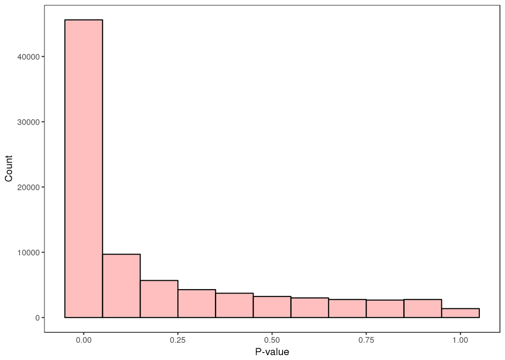

```r
factor_phist <- ggplot(data=top, aes(x=P.Value))
factor_phist <- factor_phist + geom_histogram( binwidth=0.1,
                                linetype=1,
                                alpha=.25,
                                color="black",
                                fill="red") +
                                labs(x="P-value",
                                     y= "Count")+
                                scale_y_continuous() +
                                scale_x_continuous()
ggsave(factor_phist, filename = "plots/no_accdorsal_ordinal_model_histogram_pvalues.pdf", width=11,height=8.5)
factor_phist
```

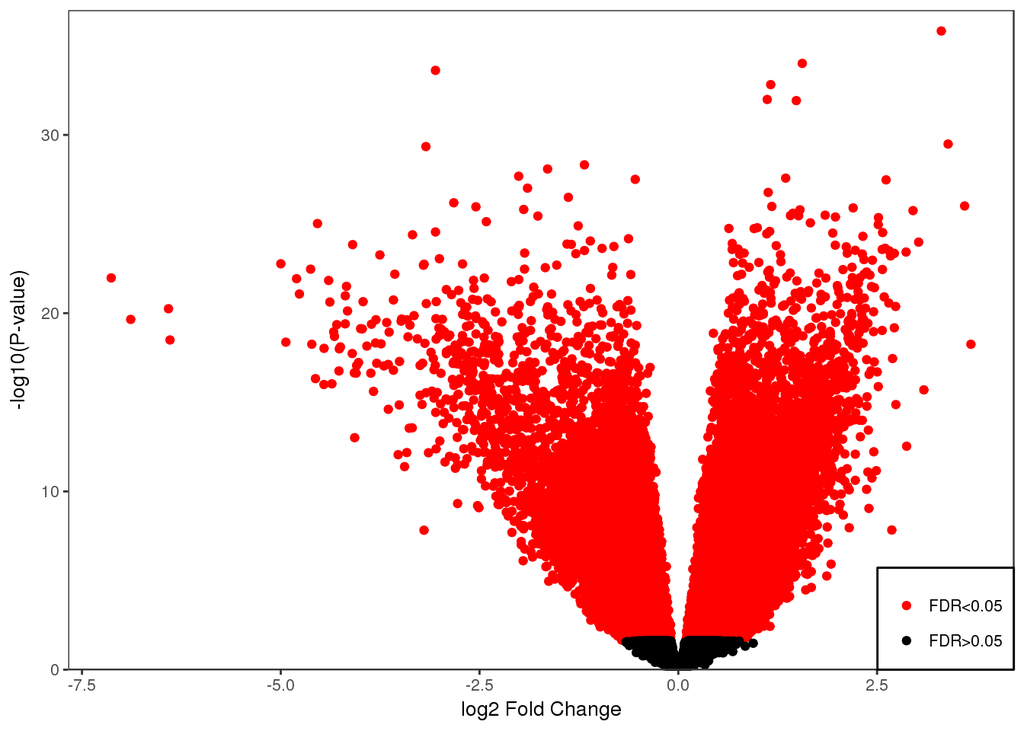

```r
top$sig = factor(ifelse(top$adj.P.Val<0.05, "FDR<0.05", "FDR>0.05"),levels=c("FDR<0.05","FDR>0.05"))
intron_volc <- ggplot(top, aes(logFC, -log10(P.Value))) +
  geom_point(aes(col=sig)) +
  theme(legend.justification = c(1, 0),
        legend.position = c(1, 0),
        legend.background = element_rect(fill=NA, size=.5, linetype="solid")) +
  labs(x = "log2 Fold Change",
       y = "-log10(P-value)") +
  scale_color_manual(values=c("red", "black")) +
    scale_y_continuous(expand = c(0, 0), limits = c(0, max(round(-log10(top$P.Value)))+1)) +
  theme(legend.background = element_rect(colour = "black"),
        legend.title=element_blank()) #no legend title
ggsave(intron_volc, filename = "plots/no_accdorsal_ordinal_model_volcano_plot_allConditions.pdf", width=11,height=8.5)
intron_volc
```

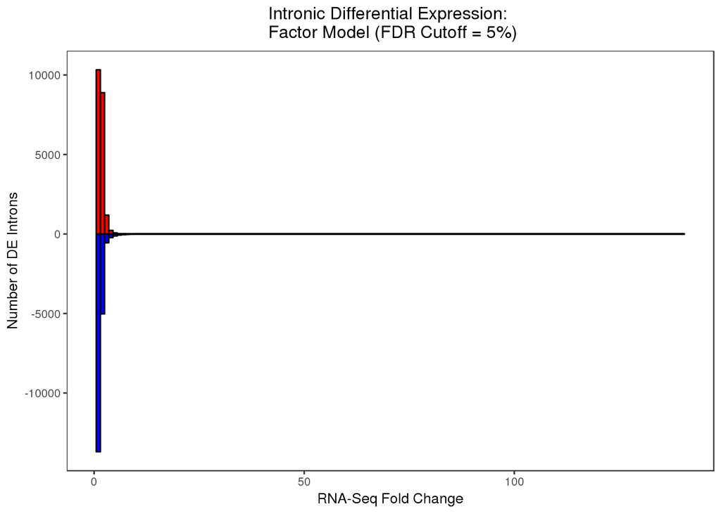

```r
histo_intron <- ggplot() +
                geom_histogram(data = top[which(top$logFC < 0 & top$adj.P.Val <0.05), ],
                          aes(x = 2^abs(logFC), y = -..count..),
                          binwidth=1,
                          fill = "blue",
                          color = "black") +
#               geom_density(data = top[which(top$logFC < 0 & top$adj.P.Val <0.05), ],
#                            aes(x = 2^abs(logFC), y=-..count.. )) +  # Overlay with transparent density plot
                geom_histogram(data = top[which(top$logFC > 0 & top$adj.P.Val <0.05), ],
                          aes(x = 2^logFC, y = ..count..),
                          binwidth=1,
                          fill = "red",
                          color = "black")+
#               geom_density(data = top[which(top$logFC > 0 & top$adj.P.Val <0.05), ])+  # Overlay with transparent density plot
            labs(x = "RNA-Seq Fold Change",
                 y = "Number of DE Introns",
                 title = "Intronic Differential Expression: \n Factor Model (FDR Cutoff = 5%)")
ggsave(histo_intron, filename = "plots/no_accdorsal_ordinal_model_intron_DE_Histogram.pdf", width=11,height=8.5)
histo_intron
```

```r
counts <- dge$counts
#residualCounts<-jaffelab::cleaningY(y = counts(ER_dds,normalized=TRUE), mod=mod, P=ncol(mod)-2)

top$row <- rownames(top)
res <- as.data.frame(top) %>%
  arrange(adj.P.Val, P.Value) %>%
  tbl_df()
topRes <- res[1:100,]

rownames(pd2) <-pd2$SAMPLE_ID
goi <- topRes$row
tcounts <- t(dge$counts[goi,]) %>%
  merge(pd2, ., by="row.names") %>%
  gather(key=gene, value=expression, (ncol(.)-length(goi)+1):ncol(.))

theme_set(theme_bw(base_size=10) +
          theme(panel.grid.major = element_blank(),
                panel.grid.minor = element_blank(),
                 plot.title = element_text(hjust = 0.5),
                legend.position="none"))
pdf("plots/OrdinalModel_No_ACCDORSAL_AstrocyteFactor_Introns_Boxplot_Catalog.pdf")
for (i in goi) {
  p <- ggplot(filter(tcounts, gene==i), aes(x=CONDITION, y=expression)) +
       geom_boxplot(outlier.colour = NA, alpha = 0.1, aes(fill = CONDITION)) +
        geom_point(alpha = 1, aes(colour = CONDITION), position = position_jitter(width = 0.2)) +
        labs(x = "Condition Group",
             y = "Intron Counts",
             title = paste0("Intron: ", ifelse(top[i,'Symbol'] !="", top[i,'Symbol'],top[i,'ensemblID']) )) +
        scale_colour_brewer(palette = "Set1") +
        scale_fill_brewer(palette = "Set1") +
        theme(axis.text.x = element_text(angle = 45, hjust = 1)) +
        geom_text(aes(x=Inf,y=Inf,hjust=1.1,vjust=1.1,label=paste0("p=", signif(top[i,'P.Value'],3) ) ))+
        scale_y_log10()
  print(p)
}
dev.off()
```

## ACC_DORSAL Only Analysis

The final model we evaluated was an ordinal model by day, only on the subset of stem-cells belong to the ACC_DORSAL group. ACC_DORSAL denotes accelerated dorsal differentation protocol.

We filtered as above.

```r
pd2<-pd[pd$CONDITION=="ACC_DORSAL(2)",]
intronCounts2<-intronCounts[,pd2$SAMPLE_ID]

dge <- DGEList(counts = intronCounts2, group = pd2$DAY)

keep <- rowMeans(cpm(dge)) >.5

###From user manual
dge <- dge[keep,,keep.lib.sizes=FALSE]
```

In this model, we used the `DAY` as the predictor, while adjusting for the effects of LINE and intron assignment rate.

```r
# Model Matrix
design = model.matrix(~ pd2$DAY + pd2$LINE +pd2$totalAssignedIntron )
pdf("plots/Limma_Voom_Introns_Plot_ACCDORSAL_byDAY.pdf",width=11,height=8.5)
v <- voom(dge, design, plot=TRUE)
dev.off()
```

```r
#Model fitting
```

```r
fit <- lmFit(v, design)
fit2 <- eBayes(fit)
top <- topTable(fit2, coef=2, sort.by = 'p',number=Inf)
top<-cbind(top,intronMap[rownames(top),])
write.csv(top,file="csvs/Introns_Differential_Expression_Results_ACCDORSAL_byDAY.csv")
DT::datatable(top[1:1000,c('Symbol',colnames(top)[!colnames(top)%in%'Symbol']  )])
```

|  | Symbol | logFC | AveExpr | t | P.Value | adj.P.Val | B | Chr | Start | End | Strand | Length | gencodeID | ensemblID | gene_type | EntrezID | Class | meanExprs | NumTx | gencodeTx |
| --- | --- | --- | --- | --- | --- | --- | --- | --- | --- | --- | --- | --- | --- | --- | --- | --- | --- | --- | --- | --- |
| i163164 | LAMC3 | -0.819718859257461 | 2.04167513183248 | -30.3646057959215 | 3.7211006902975e-35 | 3.07232678494413e-30 | 69.3068792662754 | chr9 | 131032176 | 131036165 | + | 3990 | ENSG00000050555.17 | ENSG00000050555 | protein_coding | 10319 | InGen | 0.238075033697235 | 0 |  |
| i200340 | MAP6 | 0.599936902237979 | 4.4138713020025 | 26.652991959487 | 2.43136785952747e-32 | 1.00372943660943e-27 | 63.5654714006921 | chr11 | 75588185 | 75605807 | - | 17623 | ENSG00000171533.11 | ENSG00000171533 | protein_coding | 4135 | InGen | 1.02766206032332 | 0 |  |
| i15249 | VASH2 | -0.684242829567479 | 4.4337568911236 | -24.1977791674611 | 2.76169117546563e-30 | 7.60063439674398e-26 | 58.8434366625869 | chr1 | 212974071 | 212988511 | + | 14441 | ENSG00000143494.15 | ENSG00000143494 | protein_coding | 79805 | InGen | 0.305096161245061 | 0 |  |
| i136997 | ICA1 | -0.436795412788015 | 4.2665277988956 | -23.7046399198152 | 7.50080487143191e-30 | 1.34931436406054e-25 | 57.8438415804829 | chr7 | 8128143 | 8262093 | - | 133951 | ENSG00000003147.17 | ENSG00000003147 | protein_coding | 3382 | InGen | 0.0279917169527089 | 0 |  |
| i167421 | ANKRD18CP | -0.587794075271478 | 2.89537475121472 | -23.6372697479827 | 8.6093845102831e-30 | 1.34931436406054e-25 | 57.6964418147623 | chr9 | 97187508 | 97191730 | - | 4223 | ENSG00000159712.10 | ENSG00000159712 | unprocessed_pseudogene |  | InGen | 0.414523342249496 | 0 |  |
| i156231 | HHLA1 | -1.08708720231649 | -0.568177299856678 | -23.5738356973267 | 9.80546985328318e-30 | 1.34931436406054e-25 | 55.7980868284919 | chr8 | 132079967 | 132087652 | - | 7686 | ENSG00000132297.11 | ENSG00000132297 | protein_coding | 10086 | InGen | 0.0386483777088946 | 0 |  |
| i90900 | ERVMER34-1 | -0.596656562365866 | 4.55819964888466 | -23.3074269691339 | 1.69873059677195e-29 | 1.83626234410524e-25 | 57.0228423062728 | chr4 | 52722745 | 52750929 | - | 28185 | ENSG00000226887.7 | ENSG00000226887 | protein_coding | 100288413 | InGen | 0.180521697873101 | 0 |  |
| i241460 | SNHG14 | -0.28673561685896 | 8.71247677692397 | -23.2850990861167 | 1.77921622392562e-29 | 1.83626234410524e-25 | 56.7373347335035 | chr15 | 25078996 | 25081090 | + | 2095 | ENSG00000224078.12 | ENSG00000224078 | processed_transcript |  | InGen | 30.8031983979558 | 0 |  |
| i248923 |  | -0.628549121697037 | 7.44907977566021 | -22.3836275429756 | 1.18978050543466e-28 | 1.09149141590236e-24 | 54.9217728567034 | chr15 | 39776532 | 39801200 | - | 24669 | ENSG00000259580.1 | ENSG00000259580 | processed_transcript |  | InGen | 1.52539001584439 | 0 |  |
| i167418 | ANKRD18CP | -0.519027296338741 | 2.86943828238207 | -22.0157764720668 | 2.63033779961353e-28 | 2.17173840425091e-24 | 54.3053017994113 | chr9 | 97178414 | 97179996 | - | 1583 | ENSG00000159712.10 | ENSG00000159712 | unprocessed_pseudogene |  | InGen | 0.934609106574141 | 0 |  |

[output cut: 990 more lines]

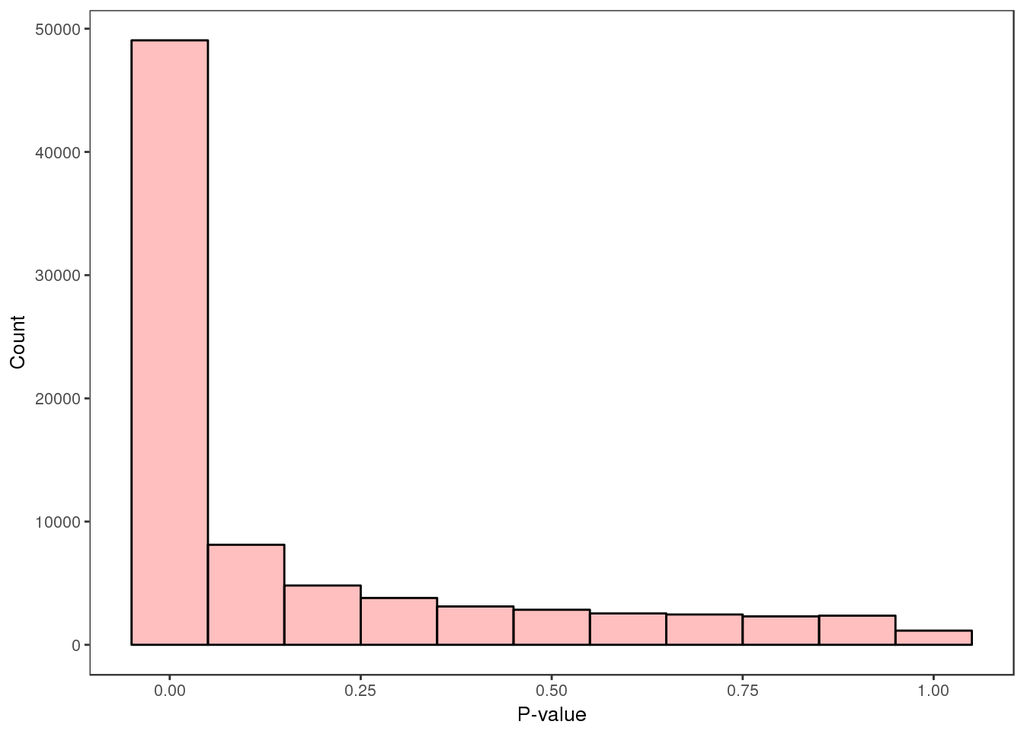

```r
factor_phist <- ggplot(data=top, aes(x=P.Value))
factor_phist <- factor_phist + geom_histogram( binwidth=0.1,
                                linetype=1,
                                alpha=.25,
                                color="black",
                                fill="red") +
                                labs(x="P-value",
                                     y= "Count")+
                                scale_y_continuous() +
                                scale_x_continuous()
ggsave(factor_phist, filename = "plots/only_accdorsal_day_model_histogram_pvalues.pdf", width=11,height=8.5)
factor_phist
```

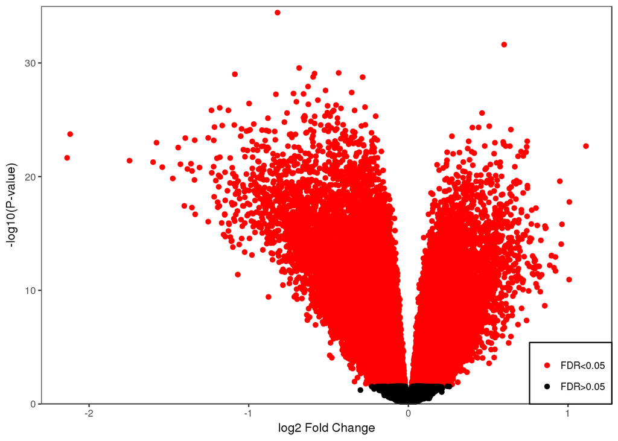

```r
top$sig = factor(ifelse(top$adj.P.Val<0.05, "FDR<0.05", "FDR>0.05"),levels=c("FDR<0.05","FDR>0.05"))
intron_volc <- ggplot(top, aes(logFC, -log10(P.Value))) +
  geom_point(aes(col=sig)) +
  theme(legend.justification = c(1, 0),
        legend.position = c(1, 0),
        legend.background = element_rect(fill=NA, size=.5, linetype="solid")) +
  labs(x = "log2 Fold Change",
       y = "-log10(P-value)") +
  scale_color_manual(values=c("red", "black")) +
    scale_y_continuous(expand = c(0, 0), limits = c(0, max(round(-log10(top$P.Value)))+1)) +
  theme(legend.background = element_rect(colour = "black"),
        legend.title=element_blank()) #no legend title
ggsave(intron_volc, filename = "plots/only_accdorsal_day_model_volcano_plot_allConditions.pdf", width=11,height=8.5)
intron_volc
```

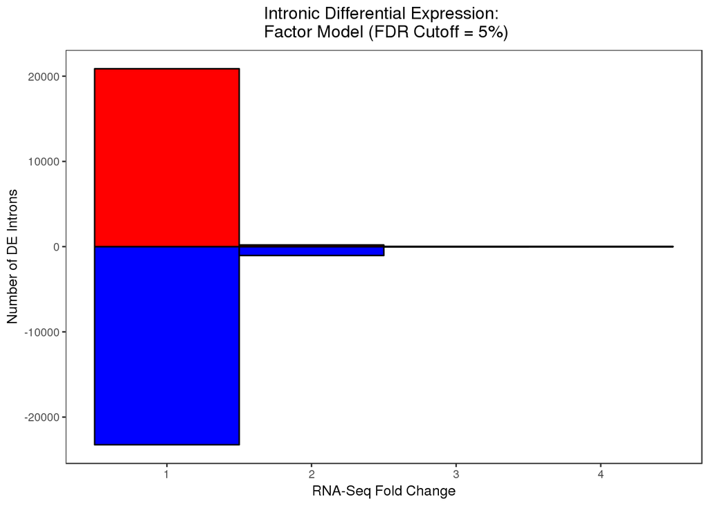

```r
histo_intron <- ggplot() +
                geom_histogram(data = top[which(top$logFC < 0 & top$adj.P.Val <0.05), ],
                          aes(x = 2^abs(logFC), y = -..count..),
                          binwidth=1,
                          fill = "blue",
                          color = "black") +
#               geom_density(data = top[which(top$logFC < 0 & top$adj.P.Val <0.05), ],
#                            aes(x = 2^abs(logFC), y=-..count.. )) +  # Overlay with transparent density plot
                geom_histogram(data = top[which(top$logFC > 0 & top$adj.P.Val <0.05), ],
                          aes(x = 2^logFC, y = ..count..),
                          binwidth=1,
                          fill = "red",
                          color = "black")+
#               geom_density(data = top[which(top$logFC > 0 & top$adj.P.Val <0.05), ])+  # Overlay with transparent density plot
            labs(x = "RNA-Seq Fold Change",
                 y = "Number of DE Introns",
                 title = "Intronic Differential Expression: \n Factor Model (FDR Cutoff = 5%)")
ggsave(histo_intron, filename = "plots/only_accdorsal_day_model_intron_DE_Histogram.pdf", width=11,height=8.5)
histo_intron
```

```r
counts <- dge$counts

#residualCounts<-jaffelab::cleaningY(y = counts(ER_dds,normalized=TRUE), mod=mod, P=ncol(mod)-2)

top$row <- rownames(top)
res <- as.data.frame(top) %>%
  arrange(adj.P.Val, P.Value) %>%
  tbl_df()
topRes <- res[1:100,]

rownames(pd2) <-pd2$SAMPLE_ID
goi <- topRes$row
tcounts <- t(dge$counts[goi,]) %>%
  merge(pd2, ., by="row.names") %>%
  gather(key=gene, value=expression, (ncol(.)-length(goi)+1):ncol(.))

pdf("plots/ACCDORSAL_byDAY_Introns_Boxplot_Catalog.pdf")
for (i in goi) {
  p <- ggplot(filter(tcounts, gene==i), aes(x=factor(DAY), y=expression)) +
       geom_boxplot(outlier.colour = NA, alpha = 0.1, aes(fill = factor(DAY))) +
        geom_point(alpha = 1, aes(colour = factor(DAY)), position = position_jitter(width = 0.2)) +
        labs(x = "Day",
             y = "Intron Counts",
             title = paste0("Accelerated Dorsal Differentiation Intron: \n", ifelse(top[i,'Symbol'] !="", top[i,'Symbol'],top[i,'ensemblID']) )) +
        scale_colour_brewer(palette = "Set1") +
        scale_fill_brewer(palette = "Set1") +
        theme(axis.text.x = element_text(angle = 0, hjust = 1)) +
        geom_text(aes(x=Inf,y=Inf,hjust=1.1,vjust=1.1,label=paste0("p=", signif(top[i,'P.Value'],3) ) ))+
        scale_y_log10()
  print(p)
}
dev.off()
```

```r
pdf("plots/ACCDORSAL_byDAY_Introns_Boxplot_Catalog_bySchizo.pdf")
for (i in goi) {
  p <- ggplot(filter(tcounts, gene==i), aes(x=factor(DAY), y=expression,fill=DX,colour=DX)) +
       geom_boxplot(outlier.colour = NA, alpha = 0.1,colour="black") +
        geom_point(alpha = 1, position = position_jitterdodge()) +
        labs(x = "Day",
             y = "Intron Counts",
             title = paste0("Accelerated Dorsal Differentiation Intron: \n", ifelse(top[i,'Symbol'] !="", top[i,'Symbol'],top[i,'ensemblID']) )) +
        scale_colour_brewer(palette = "Set1") +
        scale_fill_brewer(palette = "Set1") +
        theme(axis.text.x = element_text(angle = 0, hjust = 1)) +
        theme(legend.justification=c(0,0), legend.position=c(0,0)) +
        theme(legend.background = element_rect(colour = "black")) +
        geom_text(aes(x=Inf,y=Inf,hjust=1.1,vjust=1.1,label=paste0("p=", signif(top[i,'P.Value'],3) ) ), color='black')+
        scale_y_log10()
  print(p)
}
dev.off()
```

## Comparing Models

Lastly, we compared the results of the ACC_DORSAL model (using day as the predictor) against the results of the model on the data excluding acc_dorsal, recoding astrocytes and neurons into two seperate variables.

First we load the results for both models and merge them into a single data.frame.

```r
#################### Comparison of Results between ACC Dorsal and All others
ACC_DORSAL <- read.csv("csvs/Introns_Differential_Expression_Results_ACCDORSAL_byDAY.csv")
Normal_SC <- read.csv("csvs/Introns_Differential_Expression_Results_byCondition_OrdinalModel_No_ACCDORSAL.csv")
colnames(ACC_DORSAL) <- paste0("ACC_DORSAL_",colnames(ACC_DORSAL))
colnames(Normal_SC) <- paste0("Normal_SC_",colnames(Normal_SC))
###
library(data.table)
ACC_DORSAL<-as.data.table(ACC_DORSAL)
Normal_SC<-as.data.table(Normal_SC)

## Merging the different data results using data.table
Both_SC <- merge(ACC_DORSAL,
                 Normal_SC,
                 by.x="ACC_DORSAL_X",
                 by.y="Normal_SC_X",
                 all=FALSE)
```

We test the correlation of their t.statistics.

```r
cor.test(Both_SC$ACC_DORSAL_t,Both_SC$Normal_SC_t )
```

```
##
##  Pearson's product-moment correlation
##
## data:  Both_SC$ACC_DORSAL_t and Both_SC$Normal_SC_t
## t = 195, df = 76426, p-value < 2.2e-16
## alternative hypothesis: true correlation is not equal to 0
## 95 percent confidence interval:
##  0.5716378 0.5811064
## sample estimates:
##       cor
## 0.5763915
```

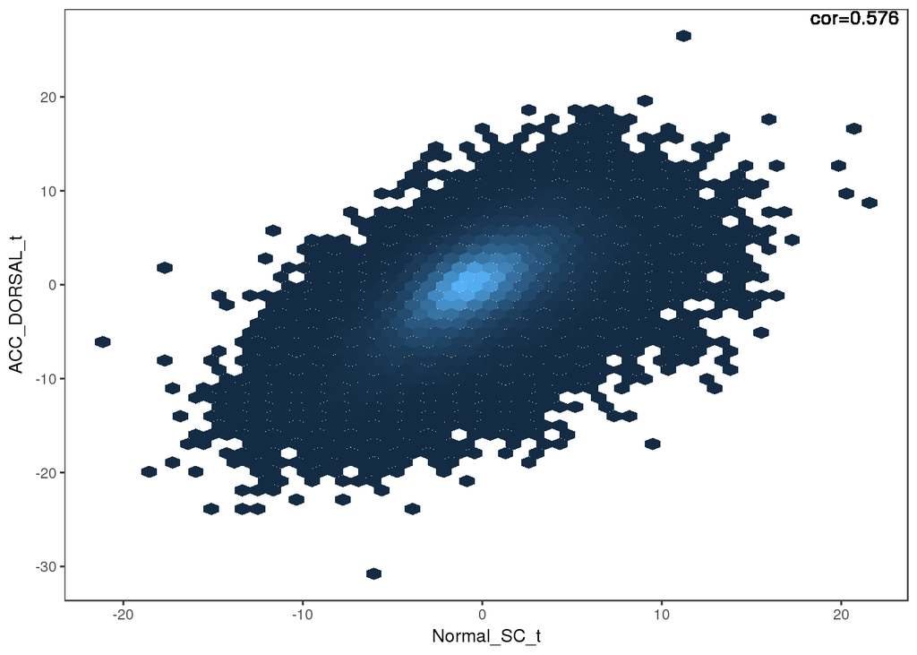

```r
# Make the plot
p <- ggplot(data =Both_SC, aes(x=Normal_SC_t, y = ACC_DORSAL_t ) )
p <- p +  stat_binhex(bins=50) +
geom_text(aes(x=Inf,y=Inf,hjust=1.1,vjust=1.1,label=paste0("cor=", signif(cor.test(Both_SC$ACC_DORSAL_t,Both_SC$Normal_SC_t)$estimate,3) ) ), color='black')
ggsave(p, filename="plots/ACC_DORSAL_versus_Normal_SC_Scatter_tplot.pdf",width=11,height=8.5)
p
```